# Exercises 1

22/11/2018

## Example 1. Ordinary least squares

We begin by generating $n=100$ equally spaced points in the interval between $0$ and $\pi$. Denote the points $\tau_i$ for $i=1,\dots,100$.

```r
# Set the number n
nn <- 100
# Generate the points
tau <- seq(0,pi,length.out=nn)
```

We can inspect the elements of `tau` by simply calling the variable.

```r
tau
```

```
##   [1] 0.00000000 0.03173326 0.06346652 0.09519978 0.12693304 0.15866630
##   [7] 0.19039955 0.22213281 0.25386607 0.28559933 0.31733259 0.34906585
##  [13] 0.38079911 0.41253237 0.44426563 0.47599889 0.50773215 0.53946541
##  [19] 0.57119866 0.60293192 0.63466518 0.66639844 0.69813170 0.72986496
##  [25] 0.76159822 0.79333148 0.82506474 0.85679800 0.88853126 0.92026451
##  [31] 0.95199777 0.98373103 1.01546429 1.04719755 1.07893081 1.11066407
##  [37] 1.14239733 1.17413059 1.20586385 1.23759711 1.26933037 1.30106362
##  [43] 1.33279688 1.36453014 1.39626340 1.42799666 1.45972992 1.49146318
##  [49] 1.52319644 1.55492970 1.58666296 1.61839622 1.65012947 1.68186273
##  [55] 1.71359599 1.74532925 1.77706251 1.80879577 1.84052903 1.87226229
##  [61] 1.90399555 1.93572881 1.96746207 1.99919533 2.03092858 2.06266184
##  [67] 2.09439510 2.12612836 2.15786162 2.18959488 2.22132814 2.25306140
##  [73] 2.28479466 2.31652792 2.34826118 2.37999443 2.41172769 2.44346095
##  [79] 2.47519421 2.50692747 2.53866073 2.57039399 2.60212725 2.63386051
##  [85] 2.66559377 2.69732703 2.72906028 2.76079354 2.79252680 2.82426006
##  [91] 2.85599332 2.88772658 2.91945984 2.95119310 2.98292636 3.01465962
##  [97] 3.04639288 3.07812614 3.10985939 3.14159265
```

We wish to generate the matrix $\bf{X}$, where the $i$th row of $\bf{X}$ is
$$\bar{\boldsymbol{x}}_{i}^{\top}=\left(1,\sin\left(\frac{\pi\tau_{i}}{2}\right),\cos\left(\frac{\pi\tau_{i}}{2}\right),\sin\left(\pi\tau_{i}\right),\cos\left(\pi\tau_{i}\right)\right).$$

```r
# Begin by generating a column of 1s
XX <- cbind(rep(1,nn))
# Make a for loop to bind columns with cos and sin values of increasing frequency
for (kk in 1:2) {
  XX <- cbind(XX,sin(pi/2*tau*kk),cos(pi/2*tau*kk))
}
# Inspect the first 5 rows of XX
head(XX)
```

```
##      [,1]       [,2]      [,3]       [,4]      [,5]
## [1,]    1 0.00000000 1.0000000 0.00000000 1.0000000
## [2,]    1 0.04982585 0.9987579 0.09952792 0.9950348
## [3,]    1 0.09952792 0.9950348 0.19806748 0.9801884
## [4,]    1 0.14898275 0.9888398 0.29464014 0.9556083
## [5,]    1 0.19806748 0.9801884 0.38828689 0.9215385
## [6,]    1 0.24666018 0.9691020 0.47807777 0.8783175
```

Set $\alpha=1$ and $\boldsymbol{\beta}^\top=(1,1,1,1)$, and $\boldsymbol{\theta}^\top=(\alpha,\boldsymbol{\beta}^\top)$. Then, for each $i$, generate
$$y_{i}=\boldsymbol{\theta}^{\top}\bar{\boldsymbol{x}}_{i}+u_{i},$$
where $u_i$ is normally distributed with mean $0$ and variance $1/4$.

```r
# Make theta vector
theta <- matrix(rep(1,5),5,1)
# Set a random seed
set.seed(200)
# Generate the y values
yy <- XX%*%theta + rnorm(nn,0,sqrt(1/4))
```

Let $\mathbf{y}^{\top}=\left(y_{1},\dots,y_{n}\right)$ and compute the ordinary least squares estimate $\boldsymbol{\theta}^*$ using the usual equation
$$\boldsymbol{\theta}^*=\left(\mathbf{X}^{\top}\mathbf{X}\right)^{-1}\mathbf{X}^{\top}\mathbf{y}.$$

```r
# Compute the ordinary least squares estimate
theta_ols <- solve(t(XX)%*%XX)%*%t(XX)%*%yy
# Inspect the obtained estimates
theta_ols
```

```
##           [,1]
## [1,] 1.0214742
## [2,] 0.9437479
## [3,] 0.9835380
## [4,] 1.0043060
## [5,] 1.0610558
```

Plot the random data with respect to $y$ and $\tau$. Also plot the true model
$$y\left(\tau\right)=\alpha+\beta_{1}\sin\left(\frac{\pi\tau}{2}\right)+\beta_{2}\cos\left(\frac{\pi\tau}{2}\right)+\beta_{3}\sin\left(\pi\tau\right)+\beta_{4}\cos\left(\pi\tau\right),$$
versus the ordinary least squares-estimated model
$$y^{*}\left(\tau\right)=\alpha^{*}+\beta_{1}^{*}\sin\left(\frac{\pi\tau}{2}\right)+\beta_{2}^{*}\cos\left(\frac{\pi\tau}{2}\right)+\beta_{3}^{*}\sin\left(\pi\tau\right)+\beta_{4}^{*}\cos\left(\pi\tau\right).$$

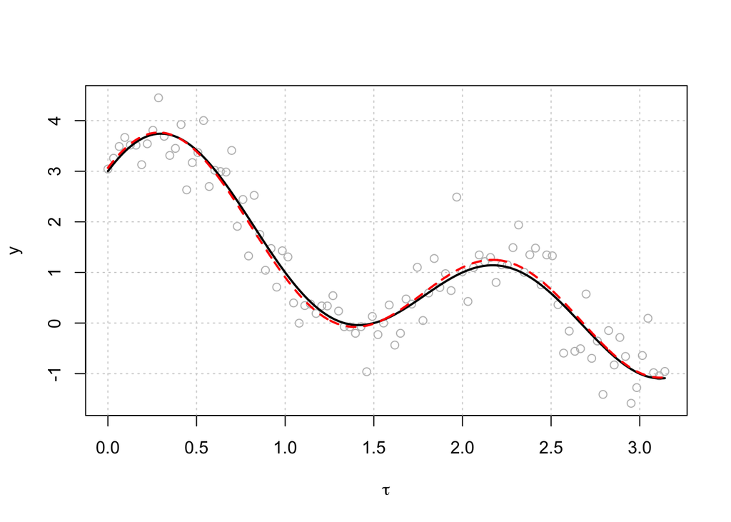

```r
# Plot the data points
plot(tau,yy,col='grey',
     xlab=expression(tau),ylab='y')
# Plot a grid in the background
grid()
# Make a dummy tau sequence for your plotting device
dum <- seq(0,pi,length.out = 1000)
# Initialize a vector of alpha (theta[1]) to store the true model values
y_true <- rep(theta[1],1000)
# Add the sin and cos values to your model
for (kk in 1:2) {
  y_true <- y_true + theta[2*kk]*sin(pi/2*dum*kk) + theta[2*kk+1]*cos(pi/2*dum*kk)
}
# Plot the true curve on top of your points, in black
lines(dum,y_true,col='black',lwd=2)
# Initialize a vector of alpha* (theta_ols[1]) to store the ols model values
y_ols <- rep(theta_ols[1],1000)
# Add the sin and cos values to your model
for (kk in 1:2) {
  y_ols <- y_ols + theta_ols[2*kk]*sin(pi/2*dum*kk) + theta_ols[2*kk+1]*cos(pi/2*dum*kk)
}
# Plot the fitted curve on top of your points, in red
lines(dum,y_ols,col='red',lwd=2,lty=2)
```

## Example 2. An MM algorithm for the median

Generate $n=10$ uniformly sampled observations, $y_i$ for $i=1,\dots,n$, between $-1$ and $1$.

```r
# Set the number of observations to generate
nn <- 10
# Set a random seed
set.seed(200)
# Generate the uniformly distributed
yy <- 2*runif(nn)-1
```

Plot the objective function
$$f\left(\theta\right)=\sum_{i=1}^{n}\left|y_{i}-\theta\right|,$$
where $\theta$ is the median variable that is to be estimated.

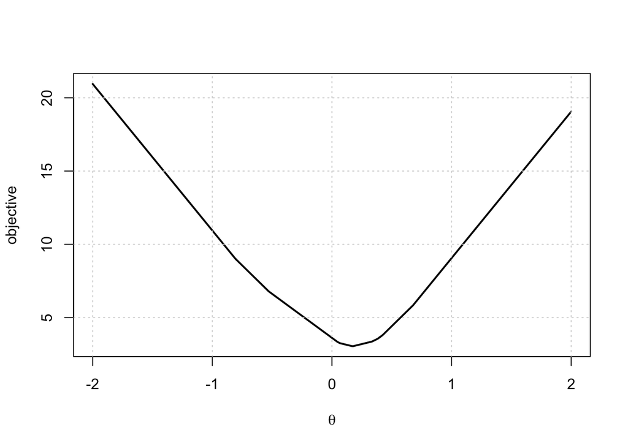

```r
# Make a dummy y sequence for your plotting device
dum <- seq(-2,2,length.out = 1000)
# Make a function that computes the objective value for any value of theta
objective <- function(theta) {
  sum(abs(yy-theta))
}
# Evaluate the objective function at each value of dum and store it in ff
ff <- sapply(dum,objective)
# Plot the objective function against the dummy sequence
plot(dum,ff,type='l',lwd=2,
     xlab=expression(theta),ylab='objective')
grid()
```

Consider the approximation to $f$
$$f_{\epsilon}\left(\theta\right)=\sum_{i=1}^{n}\sqrt{\left(y_{i}-\theta\right)^{2}+\epsilon},$$
for $\epsilon=0.01$. Plot the approximation and the true objective function together.

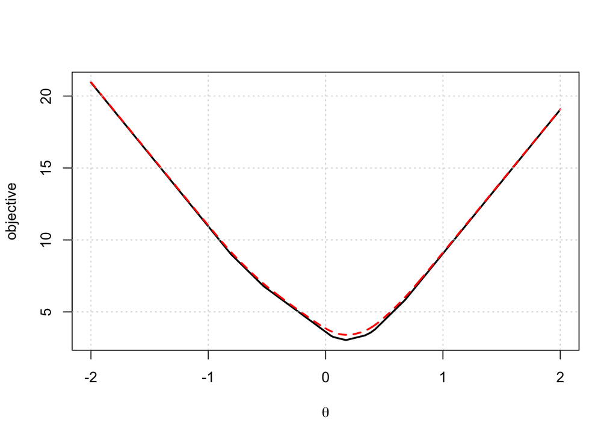

```r
# Plot the objective function again
plot(dum,ff,type='l',lwd=2,
     xlab=expression(theta),ylab='objective')
# Set the value of epsilon
epsilon <- 0.01
# Make a function that computes the approximate objective value for any value of theta
approx_obj <- function(theta) {
  sum(sqrt((yy-theta)^2+epsilon))
}
# Evaluate the approximate objective function at each value of dum and store it in ff_eps
ff_eps <- sapply(dum,approx_obj)
# Plot the approximate objective function, in red
lines(dum,ff_eps,col='red',lwd=2,lty=2)
grid()
```

> Notice the difference between the approximate objective function and the true objective function. How does the $\epsilon$ change the way in which the approximate objective function behaves?

We can majorize $f_\epsilon$ at $\theta^{\left(r-1\right)}$ using the majorizer
$$f_{\epsilon}\left(\theta,\theta^{\left(r-1\right)}\right)=\frac{1}{2}\sum_{i=1}^{n}\sqrt{\left(y_{i}-\theta^{\left(r-1\right)}\right)^{2}+\epsilon}+\frac{1}{2}\sum_{i=1}^{n}\frac{\left(y_{i}-\theta\right)^{2}+\epsilon}{\sqrt{\left(y_{i}-\theta^{\left(r-1\right)}\right)^{2}+\epsilon}}.$$

Solving the first order condition
$$\frac{\partial f_{\epsilon}\left(\cdot,\theta^{\left(r-1\right)}\right)}{\partial\theta}=-\sum_{i=1}^{n}\frac{\left(y_{i}-\theta\right)}{\sqrt{\left(y_{i}-\theta^{\left(r-1\right)}\right)^{2}+\epsilon}}=0,$$
yields the MM algorithm update scheme
$$\theta^{(r)}=\frac{\sum_{i=1}^{n}w_{i}^{\left(r-1\right)}y_{i}}{\sum_{i=1}^{n}w_{i}^{\left(r-1\right)}},$$
where
$$w_{i}^{\left(r-1\right)}=\frac{1}{\sqrt{\left(y_{i}-\theta^{\left(r-1\right)}\right)^{2}+\epsilon}}.$$
Implement the MM algorithm for $R=20$ iterations, starting from $\theta^{(0)}=-2$, and plot the solution and the approximate objective value sequences.

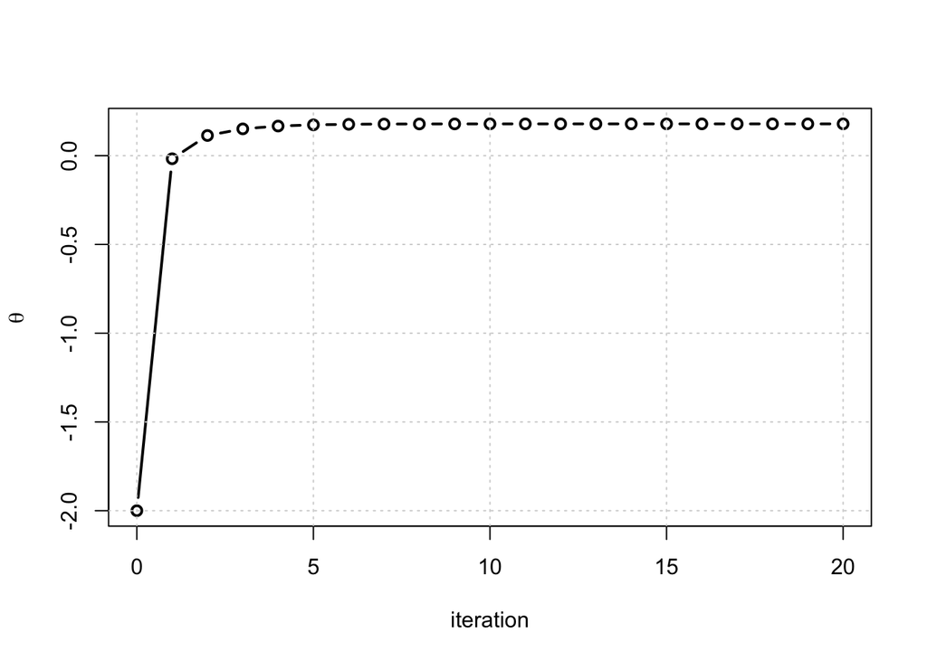

```r
# Initialize the solution sequence with a theta^(0)=-2
theta_seq <- c(-2)
# Initialize the approximate objective sequence with the value evaluated at theta = -2
obj_seq <- c(approx_obj(-2))
# Set the number of iterations R
RR <- 20
# Begin the MM algorithm loop
for (rr in 2:(RR+1)) {
  # Compute the vector of weights
  ww <- 1/sqrt((yy-theta_seq[rr-1])^2+epsilon)
  # Compute the MM algorithm solution at the current iteration
  theta_seq[rr] <- sum(ww*yy)/sum(ww)
  # Compute the current approximate objective value
  obj_seq[rr] <- approx_obj(theta_seq[rr])
}
# Plot the solution sequence
plot(0:RR,theta_seq,type='b',lwd=2,cex=1,
     xlab='iteration',ylab=expression(theta))
grid()
```

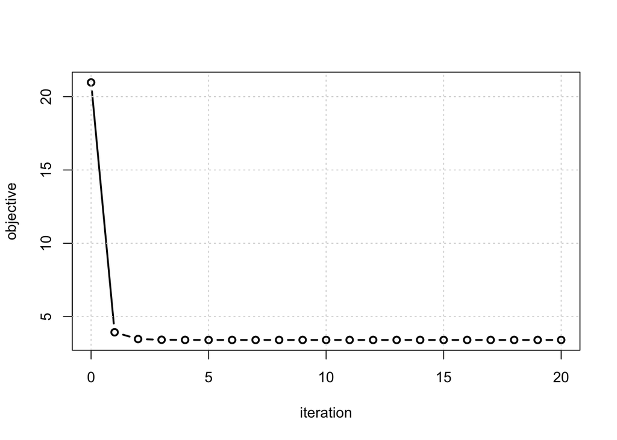

```r
# Plot the approximate objective value sequence
plot(0:RR,obj_seq,type='b',lwd=2,cex=1,
     xlab='iteration',ylab='objective')
grid()
```

Compare the MM algorithm solution with the value obtained via the `median` function.

```r
# Print the final MM algorithm solution
theta_seq[RR+1]
```

```
## [1] 0.1792493
```

```r
# Compute the median using the function in R
median(yy)
```

```
## [1] 0.1733433
```

## Exercise 1. Least absolute deviation regression

As with **Example 1** generate $n=100$ covariate vectors
$$\bar{\boldsymbol{x}}_{i}^{\top}=\left(1,\boldsymbol{x}_{i}^{\top}\right)=\left(1,\sin\left(\frac{\pi\tau_{i}}{2}\right),\cos\left(\frac{\pi\tau_{i}}{2}\right),\sin\left(\pi\tau_{i}\right),\cos\left(\pi\tau_{i}\right)\right),$$
for $\tau_i$ equally spaced between $0$ and $\pi$, and put the vectors $\bar{\boldsymbol{x}}_{i}^{\top}$ into the matrix $\bf{X}$.

Then, setting
$$\boldsymbol{\theta}^{\top}=\left(\alpha,\boldsymbol{\beta}^{\top}\right)=\left(\alpha,\beta_{1},\beta_{2},\beta_{3},\beta_{4}\right)=\left(1,2,3,4,5\right),$$
and using `set.seed(150)`, generate the responses
$$y_{i}=\boldsymbol{\theta}^{\top}\bar{\boldsymbol{x}}_{i}+u_{i},$$
where $u_i$ is normal with mean zero and variance $1/2$.

Using the generated data, fit the regression relationship
$$y\approx\alpha+\boldsymbol{\beta}^{\top}\boldsymbol{x},$$
by approximately solving the *least absolute deviation (LAD)* optimization problem
$$\min_{\boldsymbol{\theta}}\text{ }\left\{ f\left(\boldsymbol{\theta}\right)=\sum_{i=1}^{n}\left|y_{i}-\alpha-\boldsymbol{\beta}^{\top}\boldsymbol{x}_{i}\right|\right\},$$
using an MM algorithm that solves the problem
$$\min_{\boldsymbol{\theta}}\text{ }\left\{ f\left(\boldsymbol{\theta}\right)=\sum_{i=1}^{n}\sqrt{\left(y_{i}-\alpha-\boldsymbol{\beta}^{\top}\boldsymbol{x}_{i}\right)^{2}+\epsilon}\right\},$$
using $\epsilon=0.001$ and the ordinary least squares solution as an initialization.

Plot the data pairs $(\tau_i,y_i)$, the fitted ordinary least squares solution, the LAD solution, and the true model
$$y\left(\tau\right)=\alpha+\beta_{1}\sin\left(\frac{\pi\tau}{2}\right)+\beta_{2}\cos\left(\frac{\pi\tau}{2}\right)+\beta_{3}\sin\left(\pi\tau\right)+\beta_{4}\cos\left(\pi\tau\right),$$
on the same graph.

## Example 3. Sparse regression and the LASSO

We again generate $n=100$ equally spaced points in the interval between $0$ and $\pi$ and denote the points $\tau_i$ for $i=1,\dots,100$.

```r
# Set the number n
nn <- 100
# Generate the points
tau <- seq(0,pi,length.out=nn)
```

However, we now wish to generate the matrix $\bf{X}$, where the $i$th row of $\bf{X}$ is
$$\bar{\boldsymbol{x}}_{i}^{\top}=\left(1,\sin\left(\frac{\pi\tau_{i}}{2}\right),\cos\left(\frac{\pi\tau_{i}}{2}\right),\sin\left(\pi\tau_{i}\right),\cos\left(\pi\tau_{i}\right),\dots,\sin\left(\frac{\pi\tau_{i}}{2}K\right),\cos\left(\frac{\pi\tau_{i}}{2}K\right)\right),$$
and $K=10$.

```r
# Begin by generating a column of 1s
XX <- cbind(rep(1,nn))
# Set K
KK <- 10
# Make a for loop to bind columns with cos and sin values of increasing frequency
for (kk in 1:KK) {
  XX <- cbind(XX,sin(pi/2*tau*kk),cos(pi/2*tau*kk))
}
```

Set $\alpha=1$ and
$$\boldsymbol{\beta}^{\top}=(1,1,1,1,\underset{16}{\underbrace{0,\dots,0}}),$$
and $\boldsymbol{\theta}^\top=(\alpha,\boldsymbol{\beta}^\top)$. Then, for each $i$, generate
$$y_{i}=\boldsymbol{\theta}^{\top}\bar{\boldsymbol{x}}_{i}+u_{i},$$
where $u_i$ is normally distributed with mean $0$ and variance $1/4$.

```r
# Make theta vector
theta <- matrix(c(rep(1,5),rep(0,2*KK-4)),2*KK+1,1)
# Set a random seed
set.seed(200)
# Generate the y values
yy <- XX%*%theta + rnorm(nn,0,sqrt(1/4))
```

Compute the ordinary least squares estimate $\boldsymbol{\theta}^*$, using the notation $\mathbf{y}^{\top}=\left(y_{1},\dots,y_{n}\right)$, and the usual solution
$$\boldsymbol{\theta}^*=\left(\mathbf{X}^{\top}\mathbf{X}\right)^{-1}\mathbf{X}^{\top}\mathbf{y}.$$

```r
# Compute the ordinary least squares estimate
theta_ols <- solve(t(XX)%*%XX)%*%t(XX)%*%yy
# Inspect the obtained estimates
theta_ols
```

```
##              [,1]
##  [1,] -4.13061886
##  [2,]  7.51587416
##  [3,] -6.60014309
##  [4,] 10.17488329
##  [5,] -0.25028103
##  [6,]  6.74781118
##  [7,]  4.33244113
##  [8,]  1.87611656
##  [9,]  6.44592409
## [10,] -2.25734212
## [11,]  4.69767049
## [12,] -3.45434768
## [13,]  1.41644309
## [14,] -2.14232704
## [15,] -0.76079127
## [16,] -0.71806797
## [17,] -1.26933815
## [18,]  0.21947793
## [19,] -0.71790453
## [20,]  0.23764089
## [21,] -0.08104744
```

Plot the random data with respect to $y$ and $\tau$. Also plot the true model
$$y\left(\tau\right)=\alpha+\sum_{k=1}^{K}\left[\beta_{2k}\sin\left(\frac{\pi\tau}{2}k\right)+\beta_{2k+1}\cos\left(\frac{\pi\tau}{2}k\right)\right],$$
versus the ordinary least squares-estimated model
$$y^{*}\left(\tau\right)=\alpha^{*}+\sum_{k=1}^{K}\left[\beta_{2k}^{*}\sin\left(\frac{\pi\tau}{2}k\right)+\beta_{2k+1}^{*}\cos\left(\frac{\pi\tau}{2}k\right)\right].$$

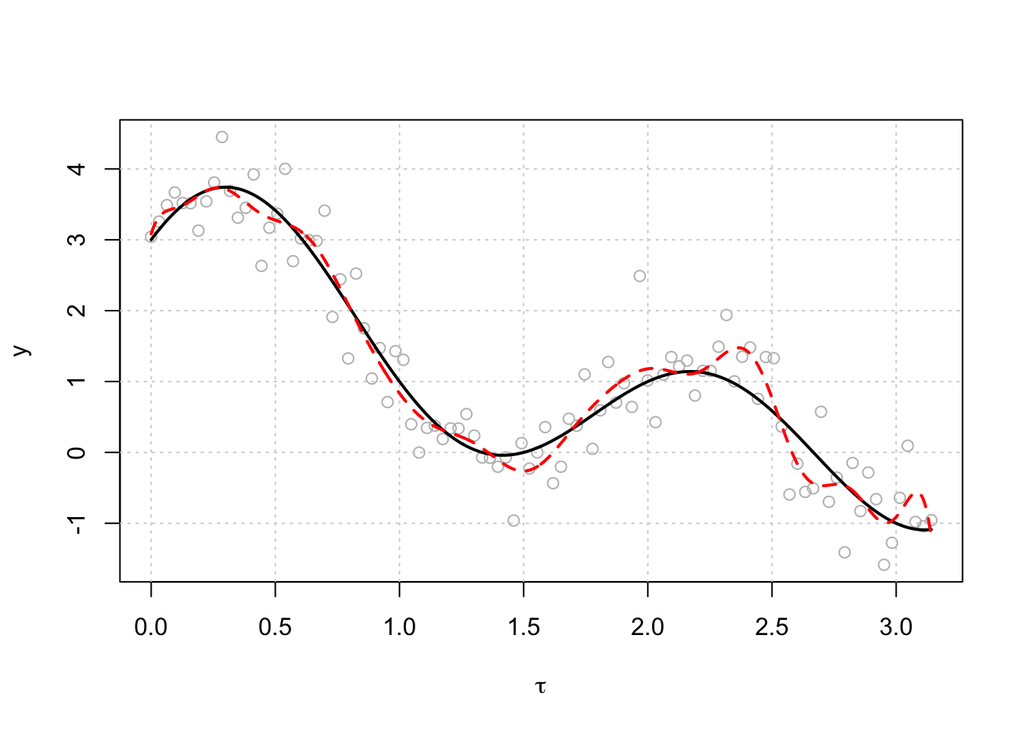

```r
# Plot the data points
plot(tau,yy,col='grey',
     xlab=expression(tau),ylab='y')
# Plot a grid in the background
grid()
# Make a dummy tau sequence for your plotting device
dum <- seq(0,pi,length.out = 1000)
# Initialize a vector of alpha (theta[1]) to store the true model values
y_true <- rep(theta[1],1000)
# Add the sin and cos values to your model
for (kk in 1:KK) {
  y_true <- y_true + theta[2*kk]*sin(pi/2*dum*kk) + theta[2*kk+1]*cos(pi/2*dum*kk)
}
# Plot the true curve on top of your points, in black
lines(dum,y_true,col='black',lwd=2)
# Initialize a vector of alpha* (theta_ols[1]) to store the ols model values
y_ols <- rep(theta_ols[1],1000)
# Add the sin and cos values to your model
for (kk in 1:KK) {
  y_ols <- y_ols + theta_ols[2*kk]*sin(pi/2*dum*kk) + theta_ols[2*kk+1]*cos(pi/2*dum*kk)
}
# Plot the fitted curve on top of your points, in red
lines(dum,y_ols,col='red',lwd=2,lty=2)
```

> Notice the difference between the ordinary least squares solution here, versus the one in Example 1. The estimated solution is overfitted to the data, here. What happens when we change the number of covariates in the model (i.e. $K$)? What happens when we change the sample size $n$? Can we obtain a sparse solution by arbitrarily increasing $n$?

We seek to implement the *LASSO* in order to obtain a solution to the problem. That is, for some *penalty* value $\lambda>0$, we wish to obtain an estimator $\boldsymbol{\theta}^*$ that solves the optimization problem:
$$\min_{\boldsymbol{\theta}}\text{ }\left\{ f\left(\boldsymbol{\theta}\right)=\sum_{i=1}^{n}\left(y_{i}-\boldsymbol{\theta}^{\top}\bar{\boldsymbol{x}}_{i}\right)^{2}+\lambda\sum_{j=1}^{d}\left|\beta_{j}\right|\right\}.$$

We shall solve the problem by using the coordinate-wise MM algorithm. Let $\boldsymbol{\theta}^{\left(r\right)}$ denote the $r$th iterate of the MM algorithm. At iteration $j$, we update the $1$st coordinate of $\boldsymbol{\theta}$ by
$$\theta_{1}^{\left(r\right)}=\theta_{1}^{\left(r-1\right)}+\frac{\sum_{i=1}^{n}\bar{x}_{i1}\left[y_{i}-\boldsymbol{\theta}^{\left(r-1\right)\top}\bar{\boldsymbol{x}}_{i}\right]}{\left(d+1\right)\sum_{i=1}^{n}\bar{x}_{i1}^{2}}.$$

For $j=2,\dots,d+1$, let
$$a_{j}^{\left(r-1\right)}=\theta_{j}^{\left(r-1\right)}+\frac{\sum_{i=1}^{n}\bar{x}_{ij}\left[y_{i}-\boldsymbol{\theta}^{\left(r-1\right)\top}\bar{\boldsymbol{x}}_{i}\right]}{\left(d+1\right)\sum_{i=1}^{n}\bar{x}_{ij}^{2}},$$
and
$$b_{j}=\frac{\lambda/2}{\left(d+1\right)\sum_{i=1}^{n}\bar{x}_{ij}^{2}}.$$

We can define the $r$th iteration update for coordinate $j>1$ as the following piecewise function:
$$\theta_{j}^{\left(r\right)}=\begin{cases}
a_{j}^{\left(r-1\right)}+b_{j} & \text{if }a_{j}^{\left(r-1\right)}<-b_{j}\text{,}\\
0 & \text{if }\left|a_{j}^{\left(r-1\right)}\right|\le b_{j}\text{,}\\
a_{j}^{\left(r-1\right)}-b_{j} & \text{if }a_{j}^{\left(r-1\right)}>b_{j}\text{.}
\end{cases}.$$

Run the MM algorithm for $R=2000$ iterations in order to fit the LASSO with $\lambda=10$. Initialize the algorithm using the least squares estimates.

```r
# Set the number of iterations R
RR <- 2000
# Set lambda
lambda <- 10
# Get the dimensionality of the vector theta
DD <- length(theta)
# Create a function that takes a (r-1)th iteration estimate and computes the rth MM iteration
MM_step <- function(theta) {
  # Make a dummy vector to store the output
  output <- c()
  # Compute the inner product t(theta)*bar{x}_i for each i and store in a vector
  inner_prod <- XX%*%matrix(theta,length(theta),1)
  # Compute the update for coordinate j=1
  output[1] <- theta[1] + sum(XX[,1]*(yy-inner_prod))/(DD*sum(XX[,1]^2))
  # Begin a loop to compute the updates for j>2
  for (jj in 2:DD) {
    # Compute a_j
    aa <- theta[jj] + sum(XX[,jj]*(yy-inner_prod))/(DD*sum(XX[,jj]^2))
    # Compute b_j
    bb <- (lambda/2)/(DD*sum(XX[,jj]^2))
    # Compute the update for theta_j
    if (aa < -bb) {
      output[jj] <- aa + bb
    }
    if (abs(aa) <= bb) {
      output[jj] <- 0
    }
    if (aa > bb) {
      output[jj] <- aa - bb
    }
  }
  # Return output from the function
  return(output)
}
# Initialize the algorithm with the ordinary least squares estimates
theta_lasso <- theta_ols
# Run the algorithm for R iterations
for (rr in 1:RR) {
  theta_lasso <- MM_step(theta_lasso)
}
# Print the output
theta_lasso
```

```
##  [1]  1.04757124  0.81377736  0.92825178  0.87109326  0.94926019
##  [6]  0.00000000 -0.04521592  0.00000000  0.00000000  0.00000000
## [11]  0.00000000  0.00000000  0.00000000  0.07739817  0.00000000
## [16]  0.00000000  0.00000000  0.00000000  0.00000000  0.00000000
## [21]  0.00000000
```

> Notice that the solution now has values that are exactly zero. This implies that the LASSO problem is able to generate sparse solutions. Controlling the value of $\lambda$ allows for modification of the sparseness of the regression solution. Is the solution sufficiently sparse? What happens when we increase $\lambda$?

Plot the data, the true model
$$y\left(\tau\right)=\alpha+\sum_{k=1}^{K}\left[\beta_{2k}\sin\left(\frac{\pi\tau}{2}k\right)+\beta_{2k+1}\cos\left(\frac{\pi\tau}{2}k\right)\right],$$
the ordinary least squares estimated model, as well as the LASSO solution
$$y^{\text{LASSO}}\left(\tau\right)=\alpha^{\text{LASSO}}+\sum_{k=1}^{K}\left[\beta_{2k}^{\text{LASSO}}\sin\left(\frac{\pi\tau}{2}k\right)+\beta_{2k+1}^{\text{LASSO}}\cos\left(\frac{\pi\tau}{2}k\right)\right].$$

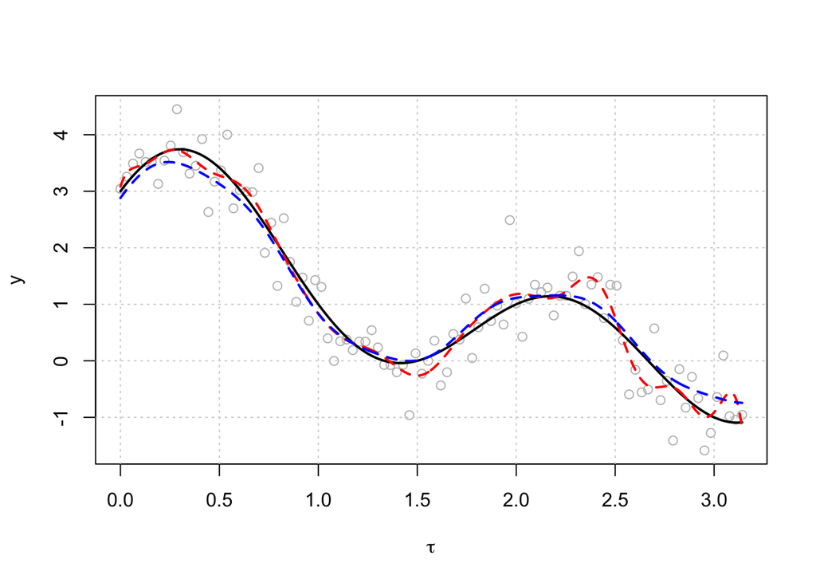

```r
# Plot the data points
plot(tau,yy,col='grey',
     xlab=expression(tau),ylab='y')
# Plot a grid in the background
grid()
# Make a dummy tau sequence for your plotting device
dum <- seq(0,pi,length.out = 1000)
# Initialize a vector of alpha (theta[1]) to store the true model values
y_true <- rep(theta[1],1000)
# Add the sin and cos values to your model
for (kk in 1:KK) {
  y_true <- y_true + theta[2*kk]*sin(pi/2*dum*kk) + theta[2*kk+1]*cos(pi/2*dum*kk)
}
# Plot the true curve on top of your points, in black
lines(dum,y_true,col='black',lwd=2)
# Initialize a vector of alpha* (theta_ols[1]) to store the ols model values
y_ols <- rep(theta_ols[1],1000)
# Add the sin and cos values to your model
for (kk in 1:KK) {
  y_ols <- y_ols + theta_ols[2*kk]*sin(pi/2*dum*kk) + theta_ols[2*kk+1]*cos(pi/2*dum*kk)
}
# Plot the fitted curve on top of your points, in red
lines(dum,y_ols,col='red',lwd=2,lty=2)
# Initialize a vector of alpha^lasso (theta_lasso[1]) to store the LASSO model values
y_lasso <- rep(theta_lasso[1],1000)
# Add the sin and cos values to your model
for (kk in 1:KK) {
  y_lasso <- y_lasso + theta_lasso[2*kk]*sin(pi/2*dum*kk) + theta_lasso[2*kk+1]*cos(pi/2*dum*kk)
}
# Plot the fitted curve on top of your points, in blue
lines(dum,y_lasso,col='blue',lwd=2,lty=2)
```

> We notice that the estimated curve is a much smoother estimate of the true curve. What happens when we increase or decrease the value of $\lambda$?

We can consider how the LASSO solution evolves as we increase the value of $\lambda$. This can be achieved by plotting the *solution curves* of each of the elements of the LASSO estimate for $\boldsymbol{\beta}$. We will do this for the sequence $\lambda$
$$\left\{ \lambda_{0},\lambda_{1},\dots,\lambda_{40}\right\} =\left\{ 0,0.5,1,\dots,20\right\}.$$

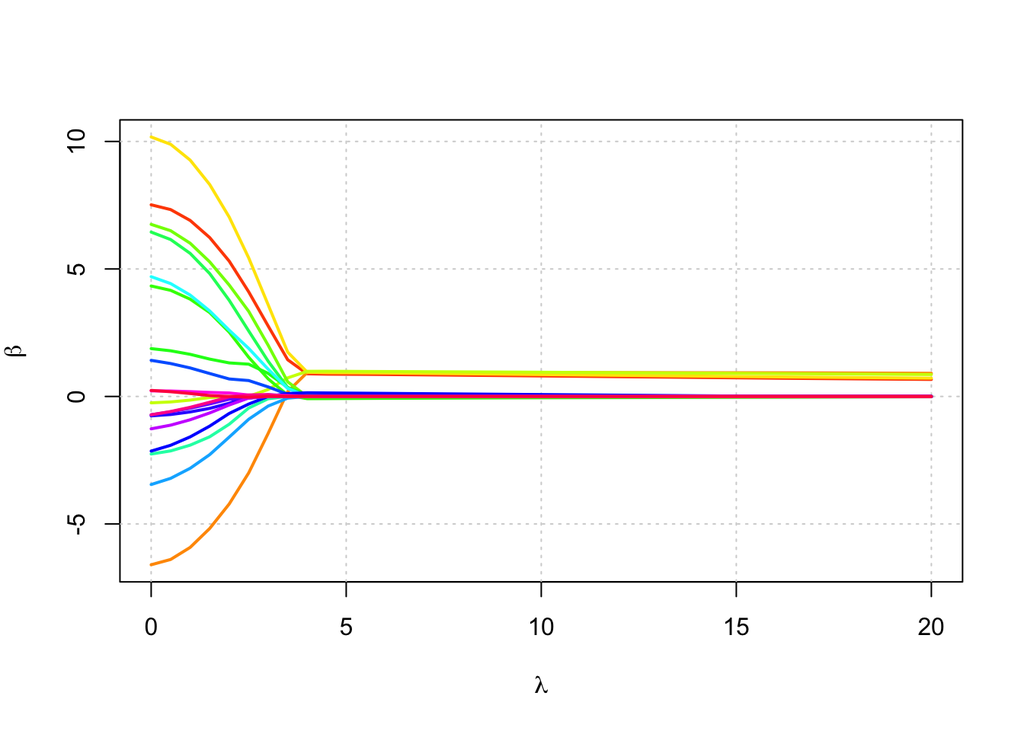

```r
# Initialize the lambda sequence
lambda_seq <- seq(0,20,by=0.5)
# Initalize a matrix for storing the LASSO solution for each lambda
theta_mat <- matrix(NA,length(lambda_seq),DD)
# Put the OLS solution in the first row of the matrix
theta_mat[1,] <- theta_ols
# Begin a for loop that computes the solution for each lambda
for (ll in 2:length(lambda_seq)) {
  # Set lambda to the current value from the sequence
  lambda <- lambda_seq[ll]
  # Initialize the theta_lasso solution based on the previous solution from the matrix
  theta_lasso <- theta_mat[ll-1,]
  # We set R to be a smaller number than the previous case, since we are initializing closer to the optimal solution than before. This reduces the computational demand of the algorithm.
  RR <- 1000
  # Run the MM algorithm for R iterations
  for (rr in 1:RR) {
    theta_lasso <- MM_step(theta_lasso)
  }
  # Put the output into the storage matrix
  theta_mat[ll,] <- theta_lasso
}
# Initialize a plot using the smallest and the largest coefficient values from the matrix
plot(c(min(lambda_seq),max(lambda_seq)),c(min(theta_mat[,-1]),max(theta_mat[,-1])),
     type='n',xlab=expression(lambda),ylab=expression(beta))
grid()
# Draw the solution path in a different color for each of the regression coefficients
for (jj in 2:DD) {
  lines(lambda_seq,theta_mat[,jj],lwd=2,col=rainbow(DD-1)[jj])
}
```

> Observe that the LASSO solution exhibits strong shrinkage for relatively small values of $\lambda$. Upon numerically inspecting the solution path, when can be say that the solution is sufficiently sparse? When can we say that the solution is over penalized?

## Exercise 2. Ridge regression

The LASSO is not the only linear regression method that can be used to overcome the *overfitting problem* observed when applying ordinary least squares in **Example 3**. An alternative method is the method of *ridge regression*.

Using the same notation as in **Example 3**, the ridge regression estimate can be obtained by solving the problem
$$\min_{\boldsymbol{\theta}}\text{ }\left\{ f\left(\boldsymbol{\theta}\right)=\sum_{i=1}^{n}\left(y_{i}-\boldsymbol{\theta}^{\top}\bar{\boldsymbol{x}}_{i}\right)^{2}+\lambda\sum_{j=1}^{d}\beta_{j}^{2}\right\},$$
for some $\lambda>0$.

If we write
$$\bar{\mathbf{I}}_{d}=\left[\begin{array}{cc}
0 & 0\\
0 & \mathbf{I}_{d}
\end{array}\right],$$
then ridge regression objective can be rewritten as
$$f\left(\boldsymbol{\theta}\right)=\left(\mathbf{y}-\mathbf{X}\boldsymbol{\theta}\right)^{\top}\left(\mathbf{y}-\mathbf{X}\boldsymbol{\theta}\right)+\lambda\boldsymbol{\theta}^{\top}\bar{\mathbf{I}}_{d}\boldsymbol{\theta}.$$

The first order condition is therefore
$$\frac{\partial f}{\partial\boldsymbol{\theta}}=-2\mathbf{X}^{\top}\left(\mathbf{y}-\mathbf{X}\boldsymbol{\theta}\right)+2\lambda\bar{\mathbf{I}}_{d}\boldsymbol{\theta}=\mathbf{0},$$
with solution
$$\boldsymbol{\theta}^{*}=\left(\mathbf{X}^{\top}\mathbf{X}+\lambda\bar{\mathbf{I}}_{d}\right)^{-1}\mathbf{X}^{\top}\mathbf{y}.$$

In `R`, we can generate a $\bar{\mathbf{I}}_{d}$ for some $d>0$, for example $d=5$, as follows.

```r
# Declare a value for d
dd <- 5
# Make the I_bar matrix
I_bar <- diag(c(0,rep(1,dd)))
# Display the matrix
I_bar
```

```
##      [,1] [,2] [,3] [,4] [,5] [,6]
## [1,]    0    0    0    0    0    0
## [2,]    0    1    0    0    0    0
## [3,]    0    0    1    0    0    0
## [4,]    0    0    0    1    0    0
## [5,]    0    0    0    0    1    0
## [6,]    0    0    0    0    0    1
```

Using the information above, estimate the regression coefficients for the data from **Example 3** using ridge regression, using $\lambda=10$. Is the solution observably smoother than the ordinary least squares solution? Is the solution sparse? Also generate the solution paths for the ridge regression estimates with $\lambda$ set as
$$\left\{ \lambda_{0},\lambda_{1},\dots,\lambda_{40}\right\} =\left\{ 0,0.5,1,\dots,20\right\}.$$
Again, what can be said regarding shrinkage and sparsity?

## Exercise 3. The elastic net

The method of *elastic net* regression combines the *LASSO* and *ridge regression* together. The elastic net estimator is defined as the solution to the problem
$$\min_{\boldsymbol{\theta}}\text{ }\left\{ f\left(\boldsymbol{\theta}\right)=\sum_{i=1}^{n}\left(y_{i}-\boldsymbol{\theta}^{\top}\bar{\boldsymbol{x}}_{i}\right)^{2}+\lambda\sum_{j=1}^{d}\left|\beta_{j}\right|+\mu\sum_{j=1}^{d}\beta_{j}^{2}\right\},$$
for $\lambda>0$ and $\mu>0$.

## Exercise 4. Calculating quantiles

The median is not the only *quantile* that can be calculated using an MM algorithm. In a similar way to the median, the $q$th quantile of $n$ scalar observations $y_1,\dots,y_n$, for $q\in(0,1)$, can be defined as the solution to the convex optimization problem
$$\min_{\theta}\left\{ f\left(\theta\right)=\sum_{i=1}^{n}g_{q}\left(y_{i}-\theta\right)\right\},$$
where
$$g_{q}\left(\theta\right)=\begin{cases}
q\theta & \text{if }\theta\ge0\text{,}\\
-\left(1-q\right)\theta & \text{if }\theta<0\text{.}
\end{cases}.$$

Using the fact that $g_{q}\left(\upsilon\right)$ can be majorized at $\psi$ by
$$\bar{g}_{q}\left(\upsilon,\psi\right)=\frac{1}{4}\left[\frac{\upsilon^{2}}{\left|\psi\right|}+\left(4q-2\right)\upsilon+\left|\psi\right|\right],$$
construct a majorizer for $f$ and derive an MM algorithm for computing the $q$th quantile of the data $y_1,\dots,y_n$. Implement the algorithm on the same data as that which is considered in **Example 2**.

Comment on whether or not this algorithm has any flaws. Can an arbitrarily good approximation to the algorithm be proposed that remedies the flaws?